# SD week2 HW 41378061

郭柏佑

2026-09-22

## 2.1.3

### a

```r
N <- 25
mean_y <- 92.5805
SE <- 0.4673
mu0 <- 91
df <- N - 1

sd_y <- SE * sqrt(N)

T0 <- (mean_y - mu0) / SE

p_value <- 2 * (1 - pt(abs(T0), df))

t_crit_95 <- qt(0.975, df)
margin_95 <- t_crit_95 * SE
CI95_lower <- mean_y - margin_95
CI95_upper <- mean_y + margin_95

sd_y; T0; p_value; CI95_upper
```

```
## [1] 2.3365
```

```
## [1] 3.382196
```

```
## [1] 0.002462992
```

```
## [1] 93.54496
```

補齊遺漏值後，由上述結果看到$p-value<\alpha$，因此拒絕$H_0$，有足夠證據顯示母體平均數$\mu$不等於91。

### b

對立假設為$\mu$不等於91 雙尾

### c

```r
mu_test <- 90
reject <- !(mu_test >= CI95_lower & mu_test <= CI95_upper)
reject
```

```
## [1] TRUE
```

$\mu_0=90$不在CI內，拒絕$H_0$

### d

```r
t_crit_99 <- qt(0.995, df)
margin_99 <- t_crit_99 * SE

CI99_lower <- mean_y - margin_99
CI99_upper <- mean_y + margin_99

t_crit_99; CI99_lower; CI99_upper
```

```
## [1] 2.79694
```

```
## [1] 91.27349
```

```
## [1] 93.88751
```

由上面輸出結果知 99%CI=
$$(91.27349,93.88751)$$
查t表得到$df=24$時，$t=2.797$ 99%CI = $92.5805\pm2.797*0.4673=92.5805\pm1.3072$

### e

```r
p_one_sided <- 1 - pt(T0, df)
p_one_sided
```

```
## [1] 0.001231496
```

## 2.20

### a

$$H_0 : \mu=120$$
$$H_a : \mu=120$$
右尾

### b

```r
days <- c(108, 124, 124, 106, 115, 138, 163, 159, 134, 139)

n <- length(days)
mean_days <- mean(days)
sd_days <- sd(days)
mu0 <- 120
alpha <- 0.01
mean_days
```

```
## [1] 131
```

```r
sd_days
```

```
## [1] 19.54482
```

```r
t_2.20_result = t.test(days, mu = mu0, conf.level = 1 - alpha)
t_2.20_result
```

```
##
##  One Sample t-test
##
## data:  days
## t = 1.7798, df = 9, p-value = 0.1088
## alternative hypothesis: true mean is not equal to 120
## 99 percent confidence interval:
##  110.914 151.086
## sample estimates:
## mean of x
##       131
```

131在CI內 因此不拒絕$H_0$，由上述結果得知，在$\alpha$ = 0.01下，沒有足夠證據支持貨架壽命>120天

### c

```r
T0 <- (mean_days - mu0) / (sd_days / sqrt(n))
df <- n - 1
p_value <- 1 - pt(T0, df)

T0; p_value
```

```
## [1] 1.779758
```

```
## [1] 0.05440887
```

由上述結果知$P-value>\alpha$ 因此一樣不拒絕$H_0$

### d

由b的程式碼已經知道99%CI = (110.914,151.086)

## 2.25

### a

$$H_0 : {\sigma_1}^2 =
{\sigma_2}^2$$
$$H_a : {\sigma_1}^2
\neq {\sigma_2}^2$$

```r
type1 <- c(65, 81, 57, 66, 82, 82, 67, 59, 75, 70)
type2 <- c(64, 71, 83, 59, 65, 56, 69, 74, 82, 79)

sd1 <- sd(type1)
sd2 <- sd(type2)

var_test_2.25_result <- var.test(type1, type2, alternative = "two.sided")

sd1; sd2; var_test_2.25_result
```

```
## [1] 9.264028
```

```
## [1] 9.366607
```

```
##
##  F test to compare two variances
##
## data:  type1 and type2
## F = 0.97822, num df = 9, denom df = 9, p-value = 0.9744
## alternative hypothesis: true ratio of variances is not equal to 1
## 95 percent confidence interval:
##  0.2429752 3.9382952
## sample estimates:
## ratio of variances
##          0.9782168
```

$P-value>\alpha$ 因此不拒絕$H_0$ 沒有足夠證據顯示兩個樣本的變異數不同

### b

$$H_0 : \mu_1 = \mu_2$$
$$H_a : \mu_1 \neq \mu_2$$

```r
t_test_2.25_result <- t.test(type1, type2,
                         alternative = "two.sided",
                         paired = FALSE,
                         var.equal = TRUE)

t_test_2.25_result
```

```
##
##  Two Sample t-test
##
## data:  type1 and type2
## t = 0.048008, df = 18, p-value = 0.9622
## alternative hypothesis: true difference in means is not equal to 0
## 95 percent confidence interval:
##  -8.552441  8.952441
## sample estimates:
## mean of x mean of y
##      70.4      70.2
```

可以看到$P-value>\alpha$ 因此不拒絕$H_0$ 兩個樣本平均燃燒時間相同

### c

1. 中的$F$檢定對常態性假設相當敏感;若母體並非常態分布，即使變異數相等，型一錯誤率也可能嚴重偏離設定的$\alpha$使結論不可靠。
2. 中的$t$檢定對常態性的違反較不敏感，尤其在兩組樣本數相同、樣本數不算太小時，即使資料稍微偏離常態，$t$檢定的效果仍大致可信。

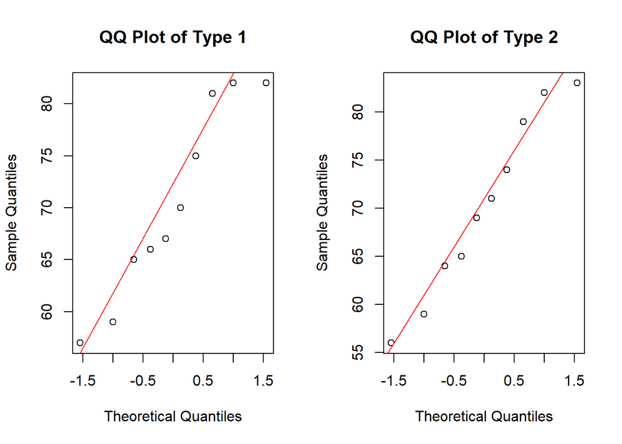

```r
par(mfrow = c(1, 2))
qqnorm(type1, main = "QQ Plot of Type 1")
qqline(type1, col = "red")
qqnorm(type2, main = "QQ Plot of Type 2")
qqline(type2, col = "red")
```

觀察兩組資料的 QQ 圖,若資料點大致沿著紅色直線分布,則支持常態性假設。我們可以看到圖中的結果基本上符合前面論述。

## 2.28

### a

$$H_0 : \mu_1 = \mu_2$$
$$H_a : \mu_1 > \mu_2$$

```r
temp95 <- c(11.176, 7.089, 8.097, 11.739, 11.291, 10.759, 6.467, 8.315)
temp100 <- c(5.265, 6.751, 7.463, 6.995, 8.103, 7.525, 3.789, 8.895)

sd95 <- sd(temp95)
sd100 <- sd(temp100)

var_test_2.28_result <- var.test(temp95, temp100, alternative = "two.sided")

sd95; sd100; var_test_2.28_result
```

```
## [1] 2.099564
```

```
## [1] 1.625519
```

```
##
##  F test to compare two variances
##
## data:  temp95 and temp100
## F = 1.6683, num df = 7, denom df = 7, p-value = 0.5157
## alternative hypothesis: true ratio of variances is not equal to 1
## 95 percent confidence interval:
##  0.3340003 8.3330131
## sample estimates:
## ratio of variances
##           1.668301
```

上面先檢定兩者變異數是否相等，結果為$P-value>\alpha$因此不拒絕變異數相等的假設 接著可以使用等變異數的$t$檢定來檢定兩組平均數是否相等

```r
t_test_2.28_result <- t.test(temp95, temp100,
                         alternative = "greater",
                         paired = FALSE,
                         var.equal = TRUE)

t_test_2.28_result
```

```
##
##  Two Sample t-test
##
## data:  temp95 and temp100
## t = 2.6826, df = 14, p-value = 0.008927
## alternative hypothesis: true difference in means is greater than 0
## 95 percent confidence interval:
##  0.8648902       Inf
## sample estimates:
## mean of x mean of y
##  9.366625  6.848250
```

結果為$P-value<\alpha$ 因此拒絕$H_0$，有足夠證據顯示較高的烘烤溫度(100°C)會使平均光阻厚度較低。

### b

$P-value=0.008927$

### c

```r
CI_2.28_result <- t.test(temp95, temp100,
                     alternative = "two.sided",
                     paired = FALSE,
                     var.equal = TRUE,
                     conf.level = 0.95)

CI_2.28_result$conf.int
```

```
## [1] 0.5048896 4.5318604
## attr(,"conf.level")
## [1] 0.95
```

### d

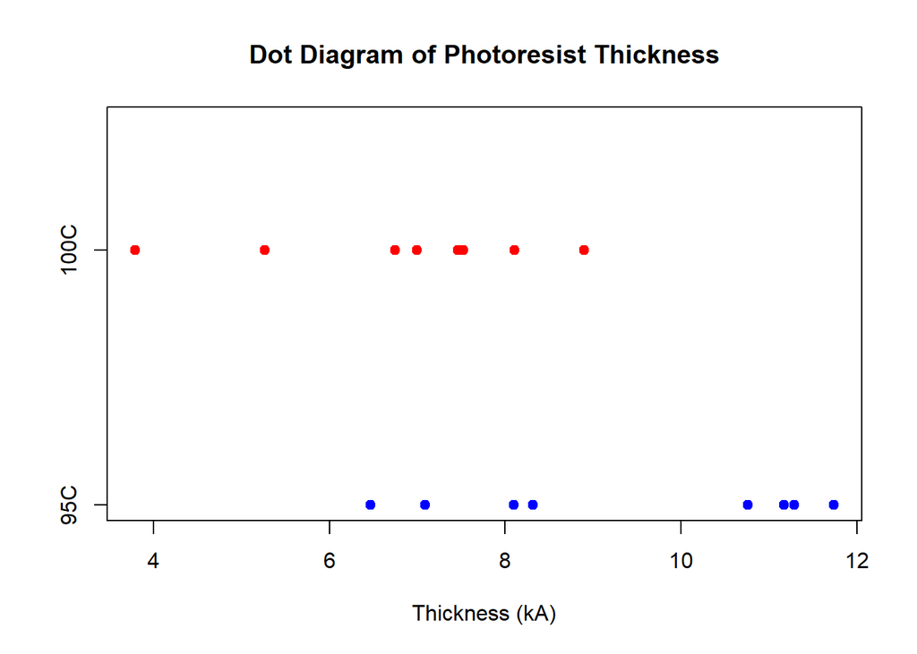

```r
stripchart(list("95C" = temp95, "100C" = temp100),
           method = "stack",
           pch = 19,
           col = c("blue", "red"),
           main = "Dot Diagram of Photoresist Thickness",
           xlab = "Thickness (kA)")
```

由點圖可觀察到95°C 組的資料點整體偏右(數值較大)，而100°C組的資料點整體偏左(數值較小)，與檢定結果相符。

### e

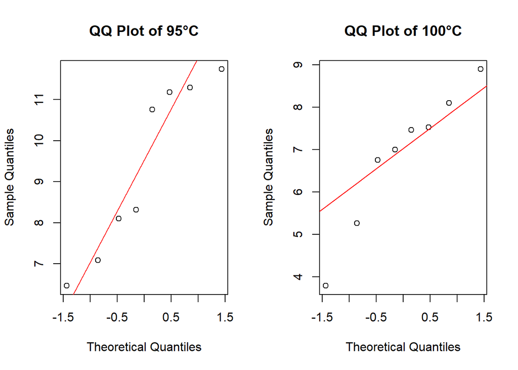

```r
par(mfrow = c(1, 2))
qqnorm(temp95, main = "QQ Plot of 95°C")
qqline(temp95, col = "red")
qqnorm(temp100, main = "QQ Plot of 100°C")
qqline(temp100, col = "red")
```

觀察兩組資料的 Q-Q 圖，資料點大致沿紅色直線分布無明顯的系統性偏離，因此常態性假設大致合理支持前述使用 t 檢定的正確性。

### f

```r
sp <- sqrt(((length(temp95) - 1) * sd95^2 + (length(temp100) - 1) * sd100^2) /
             (length(temp95) + length(temp100) - 2))

power_result <- power.t.test(n = 8, delta = 2.5, sd = sp,
                              sig.level = 0.05,
                              type = "two.sample",
                              alternative = "one.sided")

sp; power_result
```

```
## [1] 1.877562
```

```
##
##      Two-sample t test power calculation
##
##               n = 8
##           delta = 2.5
##              sd = 1.877562
##       sig.level = 0.05
##           power = 0.8122321
##     alternative = one.sided
##
## NOTE: n is number in *each* group
```

$S_p=1.877562$ 檢定力=$0.8122321$ 也就是說,在真實平均差為 2.5 kA 的情況下，以目前每組 8 個樣本,有約 81.2% 的機率能正確偵測出此差異，即拒絕$H_0$

### g

```r
n_result <- power.t.test(delta = 1.5, sd = sp,
                          sig.level = 0.05,
                          power = 0.90,
                          type = "two.sample",
                          alternative = "one.sided")

n_result
```

```
##
##      Two-sample t test power calculation
##
##               n = 27.53896
##           delta = 1.5
##              sd = 1.877562
##       sig.level = 0.05
##           power = 0.9
##     alternative = one.sided
##
## NOTE: n is number in *each* group
```

以上述結果來看，若要達到90%檢定力則至少需要28個樣本。

## 2.34

### a

$$H_0 : \mu_d = 0$$
$$H_a : \mu_d \neq 0$$

```r
karlsruhe <- c(1.186, 1.151, 1.322, 1.339, 1.200, 1.402, 1.365, 1.537, 1.559)
lehigh <- c(1.061, 0.992, 1.063, 1.062, 1.065, 1.178, 1.037, 1.086, 1.052)

diff <- karlsruhe - lehigh
mean_diff <- mean(diff)
sd_diff <- sd(diff)

t_test_2.34_result <- t.test(karlsruhe, lehigh,
                         alternative = "two.sided",
                         paired = TRUE)

mean_diff; sd_diff; t_test_2.34_result
```

```
## [1] 0.2738889
```

```
## [1] 0.1350994
```

```
##
##  Paired t-test
##
## data:  karlsruhe and lehigh
## t = 6.0819, df = 8, p-value = 0.0002953
## alternative hypothesis: true mean difference is not equal to 0
## 95 percent confidence interval:
##  0.1700423 0.3777355
## sample estimates:
## mean difference
##       0.2738889
```

由上述結果得$P-value<\alpha$，拒絕$H_0$，有足夠證據兩者在剪力強度上有顯著差異。

### c

```r
CI_result <- t.test(karlsruhe, lehigh,
                     alternative = "two.sided",
                     paired = TRUE,
                     conf.level = 0.95)

CI_result$conf.int
```

```
## [1] 0.1700423 0.3777355
## attr(,"conf.level")
## [1] 0.95
```

### d

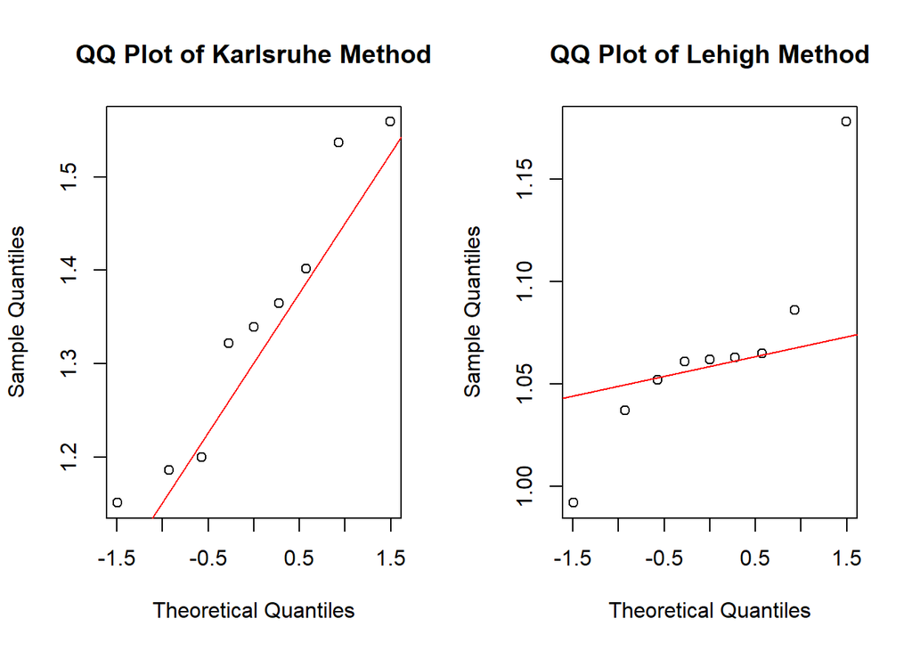

```r
par(mfrow = c(1, 2))
qqnorm(karlsruhe, main = "QQ Plot of Karlsruhe Method")
qqline(karlsruhe, col = "red")
qqnorm(lehigh, main = "QQ Plot of Lehigh Method")
qqline(lehigh, col = "red")
```

由於樣本數僅9很小的關係，Q-Q圖可能不太能夠清楚顯示常態性，但還是觀察兩組資料的圖大多點直線分布無明顯的系統性偏離，因此常態性假設大致合理。

### e

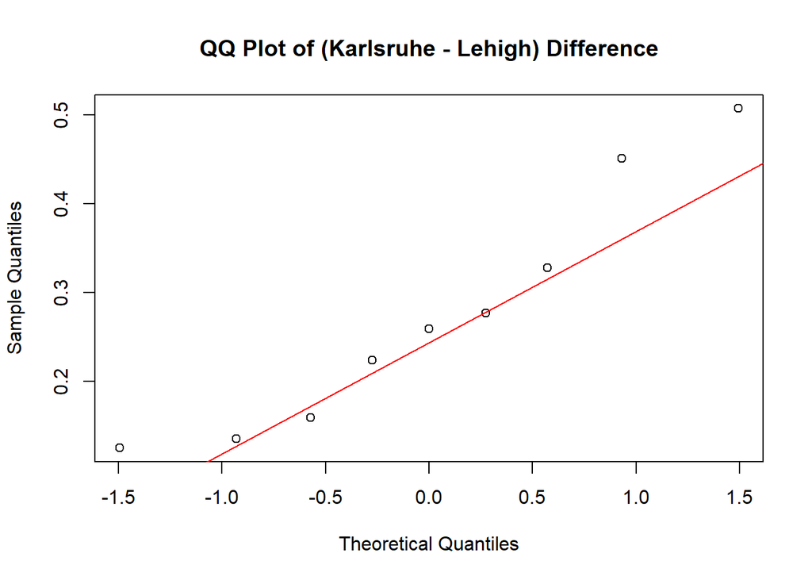

```r
qqnorm(diff, main = "QQ Plot of (Karlsruhe - Lehigh) Difference")
qqline(diff, col = "red")
```

由上面的Q-Q圖可以看到差值的點大致沿著紅線分布無明顯系統性偏離，因此支持差值$d_j = y_{1j}-y{2j}$符合常態分布的假設。

### f

配對 t 檢定的推論(如 P-value 的正確性、信賴區間的有效性)是建立在差值$d_j = y_{1j} - y_{2j}$ 服從常態分布的假設上，而不是要求兩組原始資料各自獨立地服從常態分布。 (d) 檢查的是兩組原始資料各自的常態性，這對配對 t 檢定而言並非嚴格必要的假設。 (e) 檢查的差值的常態性,才是配對 t 檢定真正依賴的假設。若差值明顯偏離常態(如樣本數小且有明顯偏態或離群值),則 t 檢定的 P-value 與信賴區間可能不準確。 由於 (e) 中差值的 QQ 圖大致呈線性,可認為本題使用配對 t 檢定是合理的。

## 2.37

### a

$$H_0 : \mu_1= \mu_2$$
$$H_a : \mu_1 \neq \mu_2$$

```r
solution1 <- c(9.9, 10.6, 9.4, 10.3, 10.0, 9.3)
solution2 <- c(10.2, 10.6, 10.0, 10.2, 10.7, 10.4)

mean1 <- mean(solution1)
mean2 <- mean(solution2)
sd1 <- sd(solution1)
sd2 <- sd(solution2)

t_test_2.37_result <- t.test(solution1, solution2,
                         alternative = "two.sided",
                         paired = FALSE,
                         var.equal = TRUE)

mean1; mean2; sd1; sd2; t_test_2.37_result
```

```
## [1] 9.916667
```

```
## [1] 10.35
```

```
## [1] 0.5036533
```

```
## [1] 0.2664583
```

```
##
##  Two Sample t-test
##
## data:  solution1 and solution2
## t = -1.8629, df = 10, p-value = 0.09208
## alternative hypothesis: true difference in means is not equal to 0
## 95 percent confidence interval:
##  -0.95163843  0.08497176
## sample estimates:
## mean of x mean of y
##  9.916667 10.350000
```

### b

```r
CI_2.37_result <- t.test(solution1, solution2,
                     alternative = "two.sided",
                     paired = FALSE,
                     var.equal = TRUE,
                     conf.level = 0.95)

CI_2.37_result$conf.int
```

```
## [1] -0.95163843  0.08497176
## attr(,"conf.level")
## [1] 0.95
```

### c

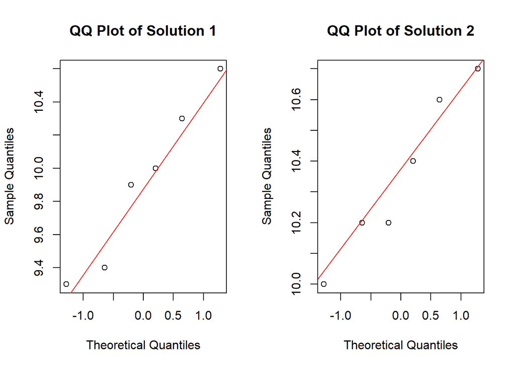

```r
par(mfrow = c(1, 2))
qqnorm(solution1, main = "QQ Plot of Solution 1")
qqline(solution1, col = "red")
qqnorm(solution2, main = "QQ Plot of Solution 2")
qqline(solution2, col = "red")
```

```r
var_2.37_test_result <- var.test(solution1, solution2, alternative = "two.sided")
var_2.37_test_result
```

```
##
##  F test to compare two variances
##
## data:  solution1 and solution2
## F = 3.5728, num df = 5, denom df = 5, p-value = 0.1886
## alternative hypothesis: true ratio of variances is not equal to 1
## 95 percent confidence interval:
##   0.4999411 25.5323783
## sample estimates:
## ratio of variances
##            3.57277
```

觀察 Q-Q 圖,兩組資料點大致沿紅線分布，無明顯系統性偏離，支持常態性假設合理，而F檢定結果也支持兩溶液變異數相等的假設，因此(a) 中使用「假設變異數相等的兩樣本 t 檢定」是合適的。